# Risk Factor Analysis

## Outcome Variable

**Outcome Variable:** dead

## Predictor Variables

**Intervention Variable:** ever_underweight06

**Adjustment Set:**

unadjusted

## Stratifying Variables

The analysis was stratified on these variable(s):

- studyid
- country

## Data Summary

| studyid | country | ever_underweight06 | dead | n_cell | n |
| --- | --- | --- | --- | --- | --- |
| Burkina Faso Zn | BURKINA FASO | 0 | 0 | 262 | 338 |
| Burkina Faso Zn | BURKINA FASO | 0 | 1 | 2 | 338 |
| Burkina Faso Zn | BURKINA FASO | 1 | 0 | 74 | 338 |
| Burkina Faso Zn | BURKINA FASO | 1 | 1 | 0 | 338 |
| EE | PAKISTAN | 0 | 0 | 103 | 380 |
| EE | PAKISTAN | 0 | 1 | 0 | 380 |
| EE | PAKISTAN | 1 | 0 | 273 | 380 |
| EE | PAKISTAN | 1 | 1 | 4 | 380 |
| GMS-Nepal | NEPAL | 0 | 0 | 388 | 697 |
| GMS-Nepal | NEPAL | 0 | 1 | 2 | 697 |
| GMS-Nepal | NEPAL | 1 | 0 | 302 | 697 |
| GMS-Nepal | NEPAL | 1 | 1 | 5 | 697 |
| iLiNS-DOSE | MALAWI | 0 | 0 | 1464 | 1816 |
| iLiNS-DOSE | MALAWI | 0 | 1 | 89 | 1816 |
| iLiNS-DOSE | MALAWI | 1 | 0 | 238 | 1816 |
| iLiNS-DOSE | MALAWI | 1 | 1 | 25 | 1816 |
| iLiNS-DYAD-M | MALAWI | 0 | 0 | 930 | 1202 |
| iLiNS-DYAD-M | MALAWI | 0 | 1 | 20 | 1202 |
| iLiNS-DYAD-M | MALAWI | 1 | 0 | 232 | 1202 |
| iLiNS-DYAD-M | MALAWI | 1 | 1 | 20 | 1202 |
| JiVitA-3 | BANGLADESH | 0 | 0 | 14424 | 27237 |
| JiVitA-3 | BANGLADESH | 0 | 1 | 240 | 27237 |
| JiVitA-3 | BANGLADESH | 1 | 0 | 11988 | 27237 |
| JiVitA-3 | BANGLADESH | 1 | 1 | 585 | 27237 |
| JiVitA-4 | BANGLADESH | 0 | 0 | 3471 | 5276 |
| JiVitA-4 | BANGLADESH | 0 | 1 | 17 | 5276 |
| JiVitA-4 | BANGLADESH | 1 | 0 | 1758 | 5276 |
| JiVitA-4 | BANGLADESH | 1 | 1 | 30 | 5276 |
| Keneba | GAMBIA | 0 | 0 | 2045 | 2632 |
| Keneba | GAMBIA | 0 | 1 | 34 | 2632 |
| Keneba | GAMBIA | 1 | 0 | 526 | 2632 |
| Keneba | GAMBIA | 1 | 1 | 27 | 2632 |
| MAL-ED | BANGLADESH | 0 | 0 | 174 | 265 |
| MAL-ED | BANGLADESH | 0 | 1 | 1 | 265 |
| MAL-ED | BANGLADESH | 1 | 0 | 88 | 265 |
| MAL-ED | BANGLADESH | 1 | 1 | 2 | 265 |
| MAL-ED | INDIA | 0 | 0 | 144 | 251 |
| MAL-ED | INDIA | 0 | 1 | 1 | 251 |
| MAL-ED | INDIA | 1 | 0 | 105 | 251 |
| MAL-ED | INDIA | 1 | 1 | 1 | 251 |
| MAL-ED | PERU | 0 | 0 | 251 | 303 |
| MAL-ED | PERU | 0 | 1 | 2 | 303 |
| MAL-ED | PERU | 1 | 0 | 50 | 303 |
| MAL-ED | PERU | 1 | 1 | 0 | 303 |
| MAL-ED | SOUTH AFRICA | 0 | 0 | 258 | 314 |
| MAL-ED | SOUTH AFRICA | 0 | 1 | 0 | 314 |
| MAL-ED | SOUTH AFRICA | 1 | 0 | 55 | 314 |
| MAL-ED | SOUTH AFRICA | 1 | 1 | 1 | 314 |
| MAL-ED | TANZANIA, UNITED REPUBLIC OF | 0 | 0 | 214 | 262 |
| MAL-ED | TANZANIA, UNITED REPUBLIC OF | 0 | 1 | 2 | 262 |
| MAL-ED | TANZANIA, UNITED REPUBLIC OF | 1 | 0 | 45 | 262 |
| MAL-ED | TANZANIA, UNITED REPUBLIC OF | 1 | 1 | 1 | 262 |
| PROVIDE | BANGLADESH | 0 | 0 | 470 | 700 |
| PROVIDE | BANGLADESH | 0 | 1 | 3 | 700 |
| PROVIDE | BANGLADESH | 1 | 0 | 226 | 700 |
| PROVIDE | BANGLADESH | 1 | 1 | 1 | 700 |
| SAS-CompFeed | INDIA | 0 | 0 | 867 | 1533 |
| SAS-CompFeed | INDIA | 0 | 1 | 16 | 1533 |
| SAS-CompFeed | INDIA | 1 | 0 | 616 | 1533 |
| SAS-CompFeed | INDIA | 1 | 1 | 34 | 1533 |
| SAS-FoodSuppl | INDIA | 0 | 0 | 194 | 416 |
| SAS-FoodSuppl | INDIA | 0 | 1 | 2 | 416 |
| SAS-FoodSuppl | INDIA | 1 | 0 | 216 | 416 |
| SAS-FoodSuppl | INDIA | 1 | 1 | 4 | 416 |
| TanzaniaChild2 | TANZANIA, UNITED REPUBLIC OF | 0 | 0 | 2110 | 2396 |
| TanzaniaChild2 | TANZANIA, UNITED REPUBLIC OF | 0 | 1 | 1 | 2396 |
| TanzaniaChild2 | TANZANIA, UNITED REPUBLIC OF | 1 | 0 | 285 | 2396 |
| TanzaniaChild2 | TANZANIA, UNITED REPUBLIC OF | 1 | 1 | 0 | 2396 |
| VITAMIN-A | INDIA | 0 | 0 | 1692 | 3906 |
| VITAMIN-A | INDIA | 0 | 1 | 10 | 3906 |
| VITAMIN-A | INDIA | 1 | 0 | 2136 | 3906 |
| VITAMIN-A | INDIA | 1 | 1 | 68 | 3906 |
| ZVITAMBO | ZIMBABWE | 0 | 0 | 10958 | 14085 |
| ZVITAMBO | ZIMBABWE | 0 | 1 | 563 | 14085 |
| ZVITAMBO | ZIMBABWE | 1 | 0 | 2019 | 14085 |
| ZVITAMBO | ZIMBABWE | 1 | 1 | 545 | 14085 |

The following strata were considered:

- studyid: Burkina Faso Zn, country: BURKINA FASO
- studyid: EE, country: PAKISTAN
- studyid: GMS-Nepal, country: NEPAL
- studyid: iLiNS-DOSE, country: MALAWI
- studyid: iLiNS-DYAD-M, country: MALAWI
- studyid: JiVitA-3, country: BANGLADESH
- studyid: JiVitA-4, country: BANGLADESH
- studyid: Keneba, country: GAMBIA
- studyid: MAL-ED, country: BANGLADESH
- studyid: MAL-ED, country: INDIA
- studyid: MAL-ED, country: PERU
- studyid: MAL-ED, country: SOUTH AFRICA
- studyid: MAL-ED, country: TANZANIA, UNITED REPUBLIC OF
- studyid: PROVIDE, country: BANGLADESH
- studyid: SAS-CompFeed, country: INDIA
- studyid: SAS-FoodSuppl, country: INDIA
- studyid: TanzaniaChild2, country: TANZANIA, UNITED REPUBLIC OF
- studyid: VITAMIN-A, country: INDIA
- studyid: ZVITAMBO, country: ZIMBABWE

### Dropped Strata

Some strata were dropped due to rare outcomes:

- studyid: Burkina Faso Zn, country: BURKINA FASO
- studyid: EE, country: PAKISTAN
- studyid: GMS-Nepal, country: NEPAL
- studyid: MAL-ED, country: BANGLADESH
- studyid: MAL-ED, country: INDIA
- studyid: MAL-ED, country: PERU
- studyid: MAL-ED, country: SOUTH AFRICA
- studyid: MAL-ED, country: TANZANIA, UNITED REPUBLIC OF
- studyid: PROVIDE, country: BANGLADESH
- studyid: SAS-FoodSuppl, country: INDIA
- studyid: TanzaniaChild2, country: TANZANIA, UNITED REPUBLIC OF

## Methods Detail

We’re interested in the causal parameters $E[Y_a]$ for all values of $a \in \mathcal{A}$. These parameters represent the mean outcome if, possibly contrary to fact, we intervened to set all units to have $A=a$. Under the randomization and positivity assumptions, these are identified by the statistical parameters $\psi_a=E_W[E_{Y|A,W}(Y|A=a,W)]$. In addition, we’re interested in the mean of $Y$, $E[Y]$ under no intervention (the observed mean). We will estimate these parameters by using SuperLearner to fit the relevant likelihood factors – $E_{Y|A,W}(Y|A=a,W)$ and $p(A=a|W)$, and then updating our likelihood fit using a joint TMLE.

For unadjusted analyses ($W=\{\}$), initial likelihoods were estimated using Lrnr_glm to estimate the simple $E(Y|A)$ and Lrnr_mean to estimate $p(A)$. For adjusted analyses, a small library containing Lrnr_glmnet, Lrnr_xgboost, and Lrnr_mean was used.

Having estimated these parameters, we will then use the delta method to estimate relative risks and attributable risks relative to a prespecified baseline level of $A$.

# Results Detail

## Results Plots

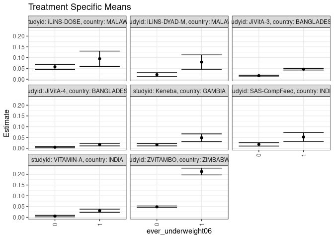

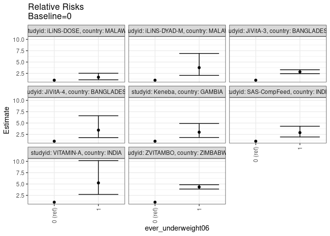

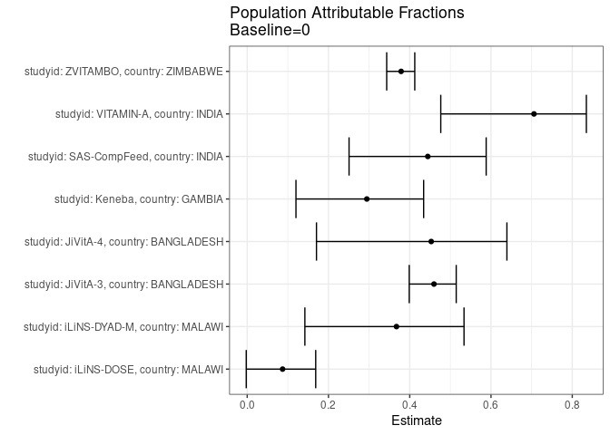

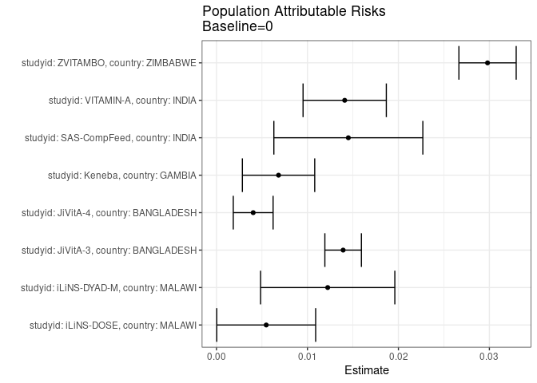

## Results Table

### Parameter: TSM

| studyid | country | intervention_level | baseline_level | estimate | ci_lower | ci_upper |
| --- | --- | --- | --- | --- | --- | --- |
| iLiNS-DOSE | MALAWI | 0 | NA | 0.0573084 | 0.0457453 | 0.0688716 |
| iLiNS-DOSE | MALAWI | 1 | NA | 0.0950570 | 0.0596008 | 0.1305133 |
| iLiNS-DYAD-M | MALAWI | 0 | NA | 0.0210526 | 0.0119199 | 0.0301853 |
| iLiNS-DYAD-M | MALAWI | 1 | NA | 0.0793651 | 0.0459773 | 0.1127528 |
| JiVitA-3 | BANGLADESH | 0 | NA | 0.0163666 | 0.0142650 | 0.0184683 |
| JiVitA-3 | BANGLADESH | 1 | NA | 0.0465283 | 0.0426922 | 0.0503643 |
| JiVitA-4 | BANGLADESH | 0 | NA | 0.0048739 | 0.0021726 | 0.0075751 |
| JiVitA-4 | BANGLADESH | 1 | NA | 0.0167785 | 0.0109081 | 0.0226490 |
| Keneba | GAMBIA | 0 | NA | 0.0163540 | 0.0109010 | 0.0218070 |
| Keneba | GAMBIA | 1 | NA | 0.0488246 | 0.0308600 | 0.0667892 |
| SAS-CompFeed | INDIA | 0 | NA | 0.0181200 | 0.0101243 | 0.0261158 |
| SAS-CompFeed | INDIA | 1 | NA | 0.0523077 | 0.0316785 | 0.0729369 |
| VITAMIN-A | INDIA | 0 | NA | 0.0058754 | 0.0022441 | 0.0095068 |
| VITAMIN-A | INDIA | 1 | NA | 0.0308530 | 0.0236329 | 0.0380731 |
| ZVITAMBO | ZIMBABWE | 0 | NA | 0.0488673 | 0.0449304 | 0.0528041 |
| ZVITAMBO | ZIMBABWE | 1 | NA | 0.2125585 | 0.1967222 | 0.2283948 |

### Parameter: E(Y)

| studyid | country | intervention_level | baseline_level | estimate | ci_lower | ci_upper |
| --- | --- | --- | --- | --- | --- | --- |
| iLiNS-DOSE | MALAWI | NA | NA | 0.0627753 | 0.0516163 | 0.0739344 |
| iLiNS-DYAD-M | MALAWI | NA | NA | 0.0332779 | 0.0231340 | 0.0434218 |
| JiVitA-3 | BANGLADESH | NA | NA | 0.0302897 | 0.0281334 | 0.0324460 |
| JiVitA-4 | BANGLADESH | NA | NA | 0.0089083 | 0.0062043 | 0.0116122 |
| Keneba | GAMBIA | NA | NA | 0.0231763 | 0.0174270 | 0.0289256 |
| SAS-CompFeed | INDIA | NA | NA | 0.0326158 | 0.0204960 | 0.0447355 |
| VITAMIN-A | INDIA | NA | NA | 0.0199693 | 0.0155816 | 0.0243570 |
| ZVITAMBO | ZIMBABWE | NA | NA | 0.0786652 | 0.0742191 | 0.0831114 |

### Parameter: RR

| studyid | country | intervention_level | baseline_level | estimate | ci_lower | ci_upper |
| --- | --- | --- | --- | --- | --- | --- |
| iLiNS-DOSE | MALAWI | 0 | 0 | 1.000000 | 1.000000 | 1.000000 |
| iLiNS-DOSE | MALAWI | 1 | 0 | 1.658692 | 1.085406 | 2.534775 |
| iLiNS-DYAD-M | MALAWI | 0 | 0 | 1.000000 | 1.000000 | 1.000000 |
| iLiNS-DYAD-M | MALAWI | 1 | 0 | 3.769841 | 2.060083 | 6.898606 |
| JiVitA-3 | BANGLADESH | 0 | 0 | 1.000000 | 1.000000 | 1.000000 |
| JiVitA-3 | BANGLADESH | 1 | 0 | 2.842878 | 2.445450 | 3.304895 |
| JiVitA-4 | BANGLADESH | 0 | 0 | 1.000000 | 1.000000 | 1.000000 |
| JiVitA-4 | BANGLADESH | 1 | 0 | 3.442558 | 1.793036 | 6.609574 |
| Keneba | GAMBIA | 0 | 0 | 1.000000 | 1.000000 | 1.000000 |
| Keneba | GAMBIA | 1 | 0 | 2.985480 | 1.817047 | 4.905261 |
| SAS-CompFeed | INDIA | 0 | 0 | 1.000000 | 1.000000 | 1.000000 |
| SAS-CompFeed | INDIA | 1 | 0 | 2.886731 | 1.935349 | 4.305795 |
| VITAMIN-A | INDIA | 0 | 0 | 1.000000 | 1.000000 | 1.000000 |
| VITAMIN-A | INDIA | 1 | 0 | 5.251180 | 2.711718 | 10.168790 |
| ZVITAMBO | ZIMBABWE | 0 | 0 | 1.000000 | 1.000000 | 1.000000 |
| ZVITAMBO | ZIMBABWE | 1 | 0 | 4.349710 | 3.897666 | 4.854181 |

### Parameter: PAR

| studyid | country | intervention_level | baseline_level | estimate | ci_lower | ci_upper |
| --- | --- | --- | --- | --- | --- | --- |
| iLiNS-DOSE | MALAWI | 0 | NA | 0.0054669 | 0.0000314 | 0.0109024 |
| iLiNS-DYAD-M | MALAWI | 0 | NA | 0.0122252 | 0.0048452 | 0.0196053 |
| JiVitA-3 | BANGLADESH | 0 | NA | 0.0139231 | 0.0119149 | 0.0159313 |
| JiVitA-4 | BANGLADESH | 0 | NA | 0.0040344 | 0.0018452 | 0.0062236 |
| Keneba | GAMBIA | 0 | NA | 0.0068223 | 0.0028455 | 0.0107991 |
| SAS-CompFeed | INDIA | 0 | NA | 0.0144957 | 0.0063071 | 0.0226844 |
| VITAMIN-A | INDIA | 0 | NA | 0.0140938 | 0.0095171 | 0.0186706 |
| ZVITAMBO | ZIMBABWE | 0 | NA | 0.0297980 | 0.0266496 | 0.0329463 |

### Parameter: PAF

| studyid | country | intervention_level | baseline_level | estimate | ci_lower | ci_upper |
| --- | --- | --- | --- | --- | --- | --- |
| iLiNS-DOSE | MALAWI | 0 | NA | 0.0870867 | -0.0023957 | 0.1685811 |
| iLiNS-DYAD-M | MALAWI | 0 | NA | 0.3673684 | 0.1419069 | 0.5335906 |
| JiVitA-3 | BANGLADESH | 0 | NA | 0.4596637 | 0.3987699 | 0.5143901 |
| JiVitA-4 | BANGLADESH | 0 | NA | 0.4528840 | 0.1704552 | 0.6391565 |
| Keneba | GAMBIA | 0 | NA | 0.2943644 | 0.1199649 | 0.4342026 |
| SAS-CompFeed | INDIA | 0 | NA | 0.4444394 | 0.2506527 | 0.5881115 |
| VITAMIN-A | INDIA | 0 | NA | 0.7057760 | 0.4763554 | 0.8346822 |
| ZVITAMBO | ZIMBABWE | 0 | NA | 0.3787945 | 0.3432907 | 0.4123788 |